# lab3cp2

## Dados

Os dados utilizados nesta atividade de agrupamento estão disponibilizados no site [kaggle.com](https://www.kaggle.com/deepmatrix/imdb-5000-movie-dataset). No dataset encontramos várias informações sobre filmes, como valor gasto para produzir o filme(em dólar), tempo de duração, nota que o filme recebeu no portal imdb, etc. Para realizar o agrupamento foram pegos apenas os filmes produzidos nos EUA e que possuíam quantidade de avaliações de usuário superior ou igual a 1000. Além disso, as variáveis selecionadas como parâmetro do agrupamento foram:

- budget: orçamento gasto na produção do filme;
- movie_facebook_likes: quantidade de likes que o filme possui no facebook(uma forma de medir a popularidade do filme no facebook);
- imdb_score: nota obtida pelo filme no portal imdb;
- director_facebook_likes: quantidade de likes que o diretor do filme possui no facebook;
- duration: duração do filme;

## Visão geral dos dados

Para dar uma visão rápida do que é encontrado nos dados, vamos ver os histogramas das variáveis selecionadas e a correlação entre elas.

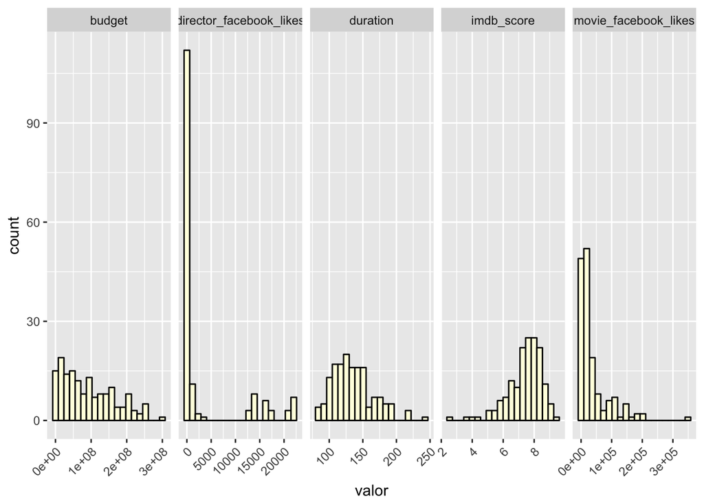

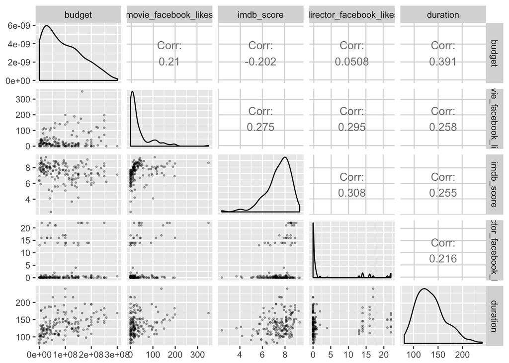

Será que existe algum padrão na observações de cada variável escolhida?

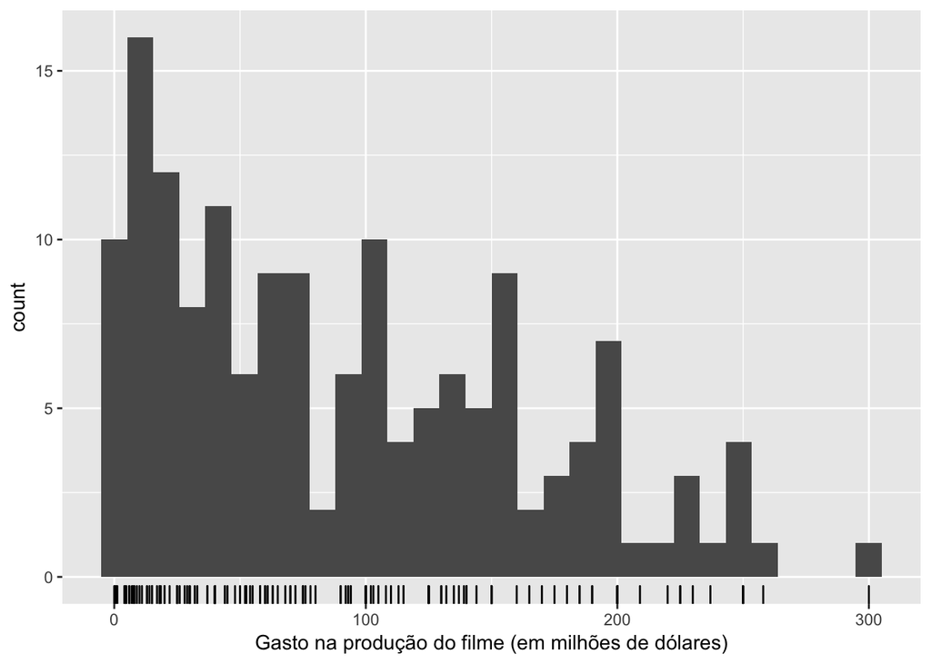

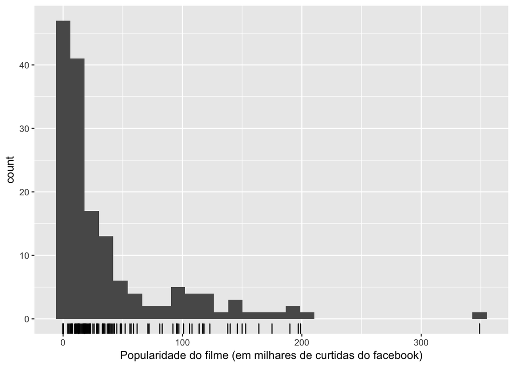

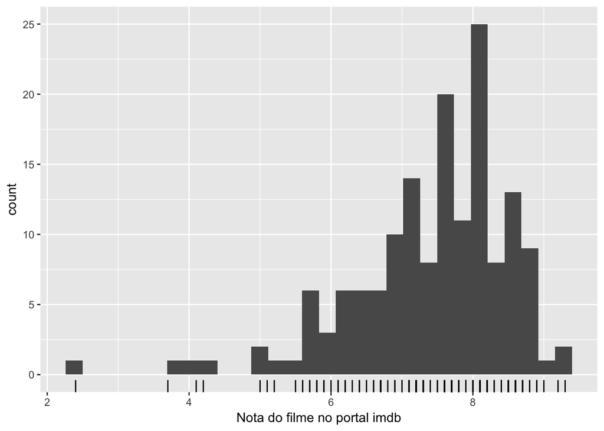

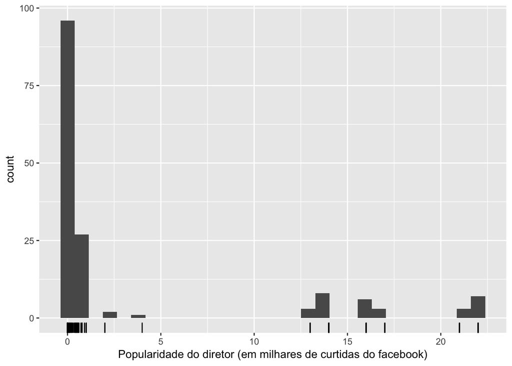

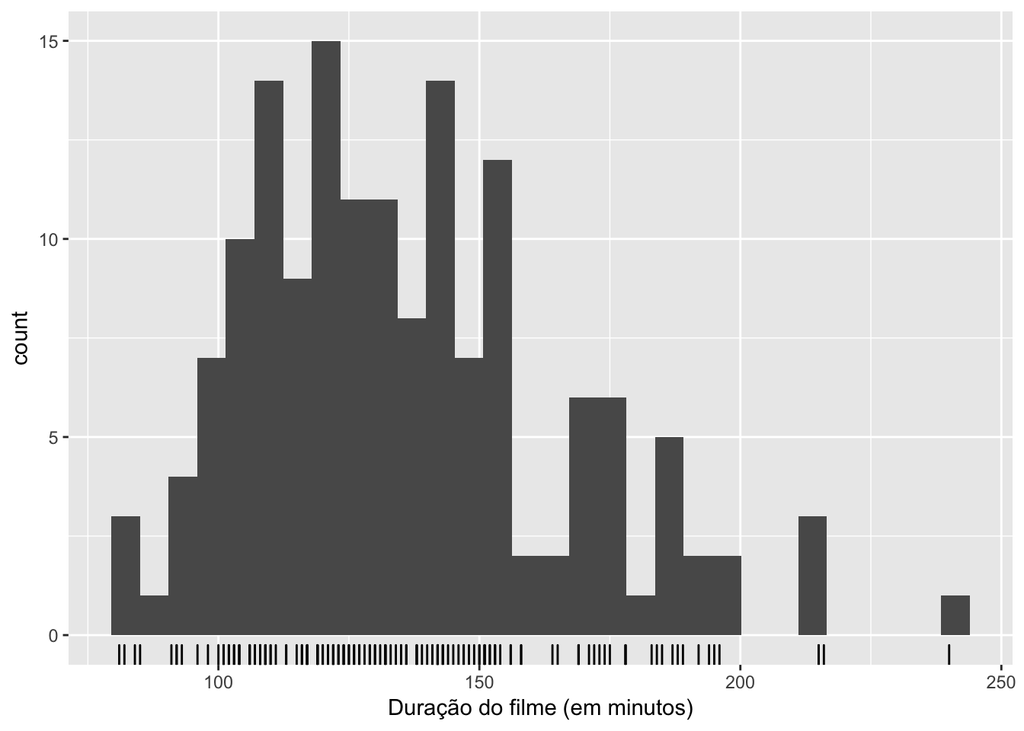

### Distribuição dos dados após normalização

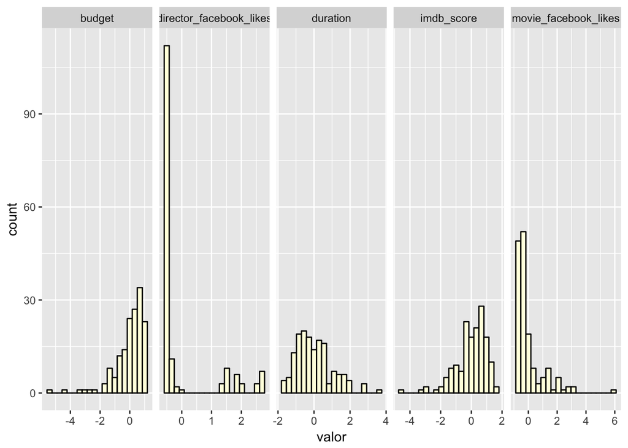

Acima mostramos como ficou a distribuição após a normalização dos dados e também com o *budget* na base log10. A maioria das ocorrências de valores são em torno da média.

## Agrupamento utilizando o hclust

Para o agrupamento iremos utilizar primeiro o hclust e fazermos uma análise hierárquica dos clusters criados.

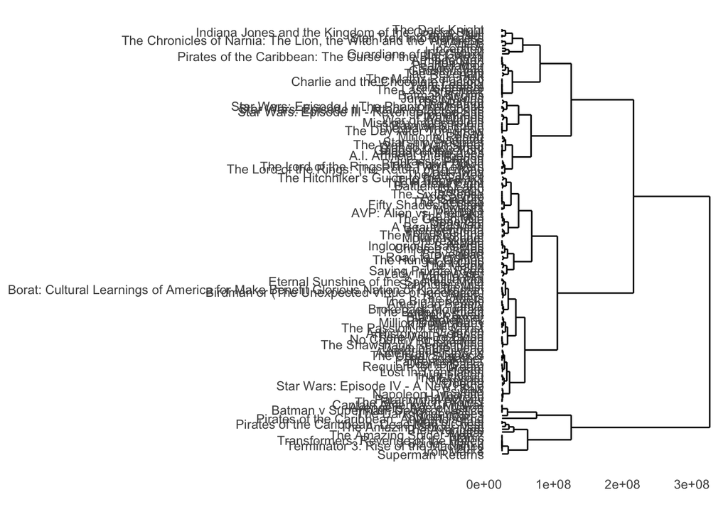

Pela grande quantidade de nomes ficou impossível ler os nomes, mas olhando para a hierarquia criada, podemos dizer que a partir de 3 clusters o salto das ligações entre cluster passou a ser maior. Vamos olhar por outro ângulo e plotar o grau de dissimilaridade à medida que o número de clusters diminui.

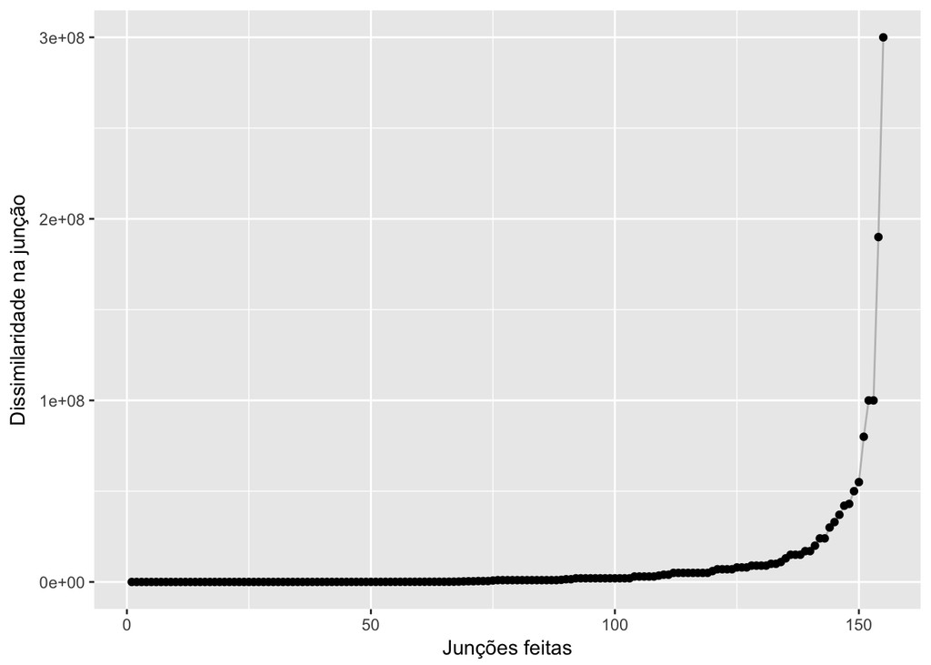

Vemos que a dissimilaridade entre os grupos quando se tem 4 ou 3 grupos é praticamente a mesma.

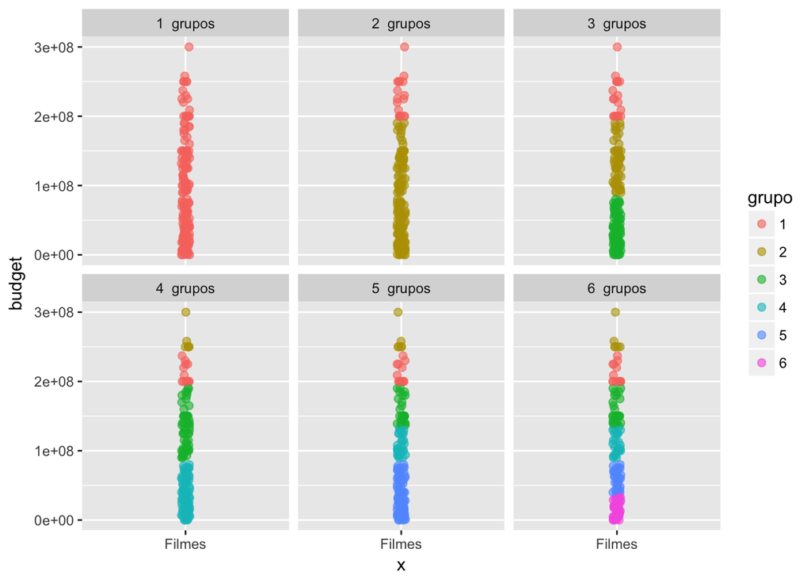

A visualização acima mostra como ficaria a divisão se tivesse de 1 a até 6 clusters.

### Silhoueta com dados normalizados

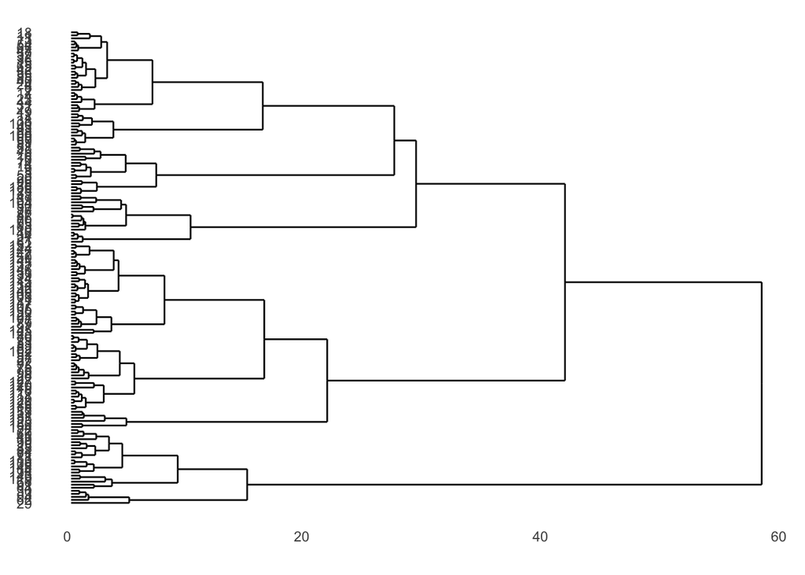

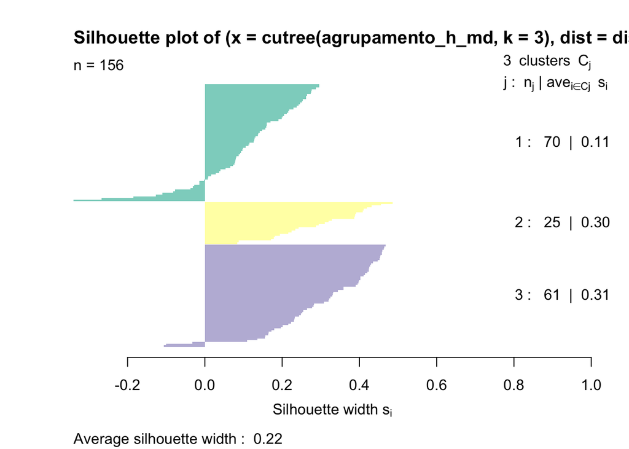

Com os dados normalizados para terem a mesma escala e divididos em 3 grupos, estes grupos ficariam formados como mostrado acima, ou seja, o grupo verde seria o maior contendo 70 filmes e alguns pontos que não se encaixaram bem no grupo, um segundo grupo amarelo com 25 filmes e nenhum estranho ao grupo e um terceiro grupo, roxo, com 61 filmes e um mínimo de dissimilaridade entre poucos filmes do grupo.

## Agrupamento utilizando o k-means

Para executar o agrupamento com o k-means começaremos buscando o número de clusters em que queremos dividir os dados.

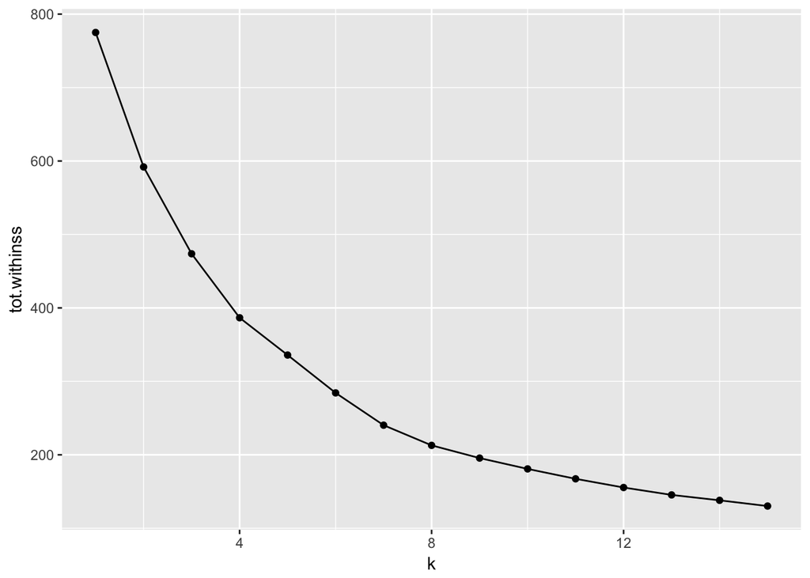

Observando esse gráfico escolheremos o valor 4 por ser o valor onde a curva começa a mudar mais bruscamente e por ser uma quantidade de clusters que ainda é fácil de observar e comparar entre si.

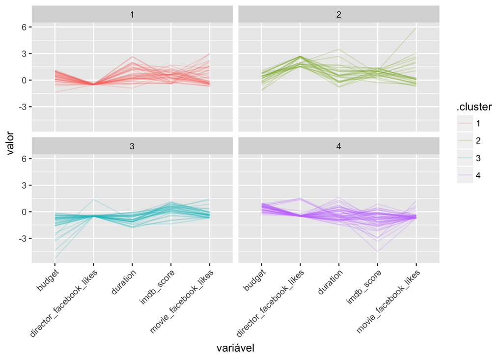

Notamos também que com as váriávei que foram escolhidas não conseguimos obter grupos tão bem definidos uns dos outros. Provavelmente, achando variáveis com valores de correlação mais extremistas, teríamos grupos mais distintos uns dos outros. Porém, agrupando com o k-means, o gráfico de silhoueta melhorou o resultado, com menos filmes que não se encaixaram tão bem no cluster em que foi alocado, como podemos ver abaixo.

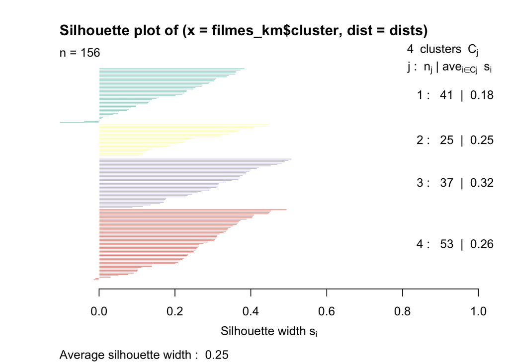